# Should we discount tomorrow?

### From a fresh-food manager's question to a specific daily recommendation

**MAIB7002 · Group Q · Lisa's pipeline extension**  
Aashish Omprakash Pareek · Yuanyuan Yin · Lingyu Chen

At the end of a trading day, a fresh-food category manager has to set tomorrow's discount before knowing how much will sell. Keeping the price high may leave stock unsold. Cutting it too far may give away value on sales that would have happened anyway. The useful answer is a decision for **one product, in one store, on one day**: keep the price, offer a particular discount, or check the situation before deciding.

Our project builds a small decision-support prototype around that question. First we learn to predict next-day sales from public retail records. Then we compare a menu of possible discounts and explain which recommendation, if any, passes our checks.

**The journey:** the business problem → suitable data → five stores worth studying → a simple forecast to beat → the teammate's evidence → Lisa's extension → the gap between predicting and deciding → a real recommendation.

No machine-learning background is needed for the main story. The technical appendix explains the algorithms, shows a live model calculation and contains the complete experiment table. Code is available at each step; in the HTML report it can be expanded when needed.

## 1. Why this decision is worth solving

Fresh food has a limited selling window. A manager who discounts too late risks unsold goods; a manager who discounts too early may earn less per sale without enough extra volume to compensate. Across many store-product combinations, it is difficult to judge these trade-offs consistently from recent sales alone. A useful assistant should make the comparison explicit, show the evidence behind it and recognize when it lacks enough information to advise.

The original project idea concerned evening bakery markdowns. The available public data led us to a more specific, feasible scope: **tomorrow's daily discount for a Dingdong store-product**. There is one recorded discount rate per day, so this study does not optimize a sequence of half-hourly markdowns.

We separate the business ambition from what this dataset lets us measure:

| What the manager ultimately cares about | What this project can check |
| --- | --- |
| Sell perishable goods without unnecessary discounting | Whether next-day forecast accuracy improves on a simple recent-sales average |
| Choose whether to discount and by how much | Whether a suggested rate has historical support and passes explicit sales/value checks |
| Increase revenue and reduce waste | These are motivations; the dataset does not let us verify those outcomes for a new policy |

This gives us two connected tasks. **Forecasting** produces a sales estimate that we can compare with a recorded outcome. **Decision support** uses several forecasts to compare hypothetical discounts. An accurate forecast is necessary evidence for this approach, but does not by itself validate the decision.

## 2. Why use these data?

We use [Dingdong's FreshRetailNet-50K](https://huggingface.co/datasets/Dingdong-Inc/FreshRetailNet-50K), a public dataset licensed CC BY 4.0. It contains actual retail records rather than demand generated by our own simulator. It is a useful fit because the same products are observed over time at different stores, alongside daily discounts, sales, calendar information and stockout signals.

One row describes **one store, one product and one date**. A store-product *series* is that pair's history across dates. The same product in two stores forms two separate series: its sales history must not be mixed across locations.

| Available evidence | How it helps the decision | What it does not establish |
| --- | --- | --- |
| Daily sales and discounts | Learn how recorded sales vary with recent history and price conditions | What would have sold at every alternative price |
| Previous-day stockout hours | Flag that observed sales may be constrained by availability | Stock quantity, batch age or tomorrow's freshness |
| Calendar and activity information | Describe the context known at the decision time | Tomorrow's realized sales or realized stockouts |
| Store and product identifiers | Distinguish recurring trading contexts | Store names, customer profiles or product shelf life |

The sales field is **normalized observed sales**. A value such as 1.2 is not 1.2 items, kilograms or dollars. If stock is unavailable, recorded sales can also understate customers' demand. These facts shape both our prediction target and the language we use for the final recommendation.

The full source covers 50,000 store-product series in 898 stores across 18 cities. Its original training file spans 90 days, followed by a seven-day evaluation file. The download script obtains a fixed version from Hugging Face, verifies it, and stores it locally. The delivered notebook includes small derived artifacts so the story and live example can also run offline.

That still leaves an important design choice: which part of this large dataset can support a manageable, meaningful first pricing study?

## 3. How 50,000 histories became five stores

A product that is always full price tells us little about different discounts. A product that is always on promotion offers little comparison with ordinary trading. We therefore keep store-product histories with both kinds of days and repeated changes between them.

We follow the teammate's original selection exactly:

| Selection rule | Reason for using it |
| --- | --- |
| Discounted on 15%–85% of training days | Retain both discounted and non-discounted observations |
| At least six switches between those states | Avoid relying on just one long promotion period |
| Zero sales on fewer than 20% of days | Avoid histories dominated by zero recorded activity |

For this selection step, a day is classified as discounted only when the price rate is **below 0.95**: more than 5% off. A day at exactly 0.95 is on the other side of this particular threshold. A change from 0.90 to 0.80 does not count as a state switch because both are already discounted.

After filtering the histories, we count how many eligible products each store has and choose the **five stores with the most eligible series**. We did not first choose a city or select stores because their models scored well. All five selected stores happen to be in city 0. We then keep only their eligible products, rather than every product sold in those stores.

**Show Python for this step**

```python
from pathlib import Path
import sys, json, hashlib, subprocess
ROOT = Path.cwd()
if not (ROOT / "src").exists():
    raise RuntimeError("Open this notebook from the repository root")
sys.path.insert(0, str(ROOT / "src"))
import numpy as np
import pandas as pd
import matplotlib.pyplot as plt
from IPython.display import display, Markdown
from finalproject_pricingml import config as C, v2
from finalproject_pricingml import storytelling as story
OUT = ROOT / "results" / "v2"
pd.set_option("display.precision", 5)
%matplotlib inline

# Read verified saved results; the appendix performs three modest worked-example fits.
# Full experiments use the explicit CLI recipe in appendix C, including dependent diagnostics.
verification = v2.verify_saved(OUT)
feat = pd.read_parquet(OUT / "features.parquet")
plan = json.loads((OUT / "experiment_plan.json").read_text())
selection = json.loads((OUT / "selection.json").read_text())
comparison = pd.read_csv(OUT / "comparison.csv")
metrics = comparison.set_index("model")
winner = selection["selected_model"]
test_predictions = pd.read_csv(OUT / "test_predictions.csv", parse_dates=["dt"])
evidence = json.loads((OUT / "story_evidence.json").read_text())
for key, filename in [("features","features.parquet"), ("discount_response","discount_response.csv"),
                      ("recommendations","recommendations.csv"), ("policy_summary","policy_summary.json")]:
    assert hashlib.sha256((OUT/filename).read_bytes()).hexdigest() == evidence["inputs_sha256"][key], "Rebuild story evidence after changing results"
assert evidence["inputs_sha256"]["raw_train"] == plan["raw_sha256"]["train"]
policy = json.loads((OUT / "policy_summary.json").read_text())
recs = pd.read_csv(OUT / "recommendations.csv", parse_dates=["dt"])
responses = pd.read_csv(OUT / "discount_response.csv", parse_dates=["dt"])
print("Saved experiment verified. No full model search is run by default.")
```

```
Saved experiment verified. No full model search is run by default.
```

**Show Python for this step**

|  | Selection stage | Store-product series |
| --- | --- | --- |
| 0 | Public training histories | 50000 |
| 1 | Keep 15%–85% discounted days | 28219 |
| 2 | Also require at least six state switches | 17693 |
| 3 | Also require fewer than 20% zero-sales days | 16684 |
| 4 | Eligible histories in the selected five stores | 312 |

|  | Store ID | City ID | Eligible products |
| --- | --- | --- | --- |
| 0 | 343 | 0 | 64 |
| 1 | 18 | 0 | 64 |
| 2 | 235 | 0 | 63 |
| 3 | 182 | 0 | 61 |
| 4 | 154 | 0 | 60 |

```
Distinct products across these stores: 122
```

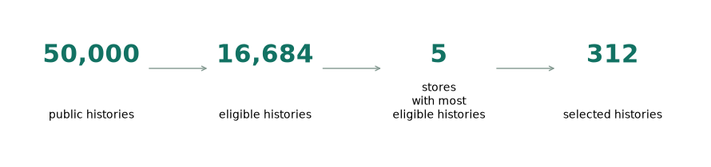

```python
funnel = evidence["selection_funnel"]
display(pd.DataFrame([
    ["Public training histories", funnel["all_series"]],
    ["Keep 15%–85% discounted days", funnel["after_discount_share_filter"]],
    ["Also require at least six state switches", funnel["after_discount_share_and_switch_filters"]],
    ["Also require fewer than 20% zero-sales days", funnel["after_all_three_filters"]],
    ["Eligible histories in the selected five stores", funnel["selected_series_in_top_five"]],
], columns=["Selection stage", "Store-product series"]))
stores = pd.DataFrame(funnel["top_five_stores_ranked"])
display(stores[["store_id", "city_id", "n_eligible"]].rename(columns={
    "store_id": "Store ID", "city_id": "City ID", "n_eligible": "Eligible products"}))
print("Distinct products across these stores:", funnel["selected_unique_products"])
assert len(feat[C.KEY].drop_duplicates()) == funnel["selected_series_in_top_five"]
fig, ax = plt.subplots(figsize=(9, 2.2))
ax.axis("off")
steps = [("50,000", "public histories"),
         (f'{funnel["after_all_three_filters"]:,}', "eligible histories"),
         ("5", "stores with most eligible histories"), ("312", "selected histories")]
for i, (count, label) in enumerate(steps):
    x = .12 + i*.25
    ax.text(x, .64, count, ha="center", fontsize=22, color="#127263", fontweight="bold")
    ax.text(x, .27, label.replace(" with most ", "\nwith most\n"), ha="center", fontsize=10)
    if i < 3:
        ax.annotate("", xy=(x+.17,.6), xytext=(x+.08,.6), arrowprops={"arrowstyle":"->", "color":"#82988f"})
fig.tight_layout(); plt.show()
```

The result is **312 store-product histories involving 122 different products**. This keeps comparisons manageable and gives each retained series some recorded discount variation. It does not make discounts random, or make these stores representative of all fresh-food retailers.

There is also a selection limitation: these rules use the entire original 90-day training file, including dates later than the first validation week. This is a retrospective working cohort. A stricter future study should choose the cohort before the first validation period, or repeat selection inside each training fold. We keep this same cohort here so the teammate and Lisa comparisons use the same cases.

### 3.1 Is there enough variation to make this a useful study?

The selection rules give us a workable sample; they do not yet show what trading looks like. Before modelling, we inspect the selected histories using **training-period rows only**. The following evidence connects discount frequency, observed sales and stock availability. If price barely changed, we would have little basis for comparing alternatives; if sales were often limited by stockouts, a low recorded sale would not necessarily mean low customer demand.

Any sales-by-discount comparison here is descriptive. Discounts were chosen by managers, not randomly assigned by this project. A higher observed average on discounted days motivates including the price condition in a forecast; it does not measure what changing the price alone would cause.

**Show Python for this step**

|  | band | rows | mean_relative_sales | stockout_share | row_share |
| --- | --- | --- | --- | --- | --- |
| 0 | Deep: rate <= 0.80 | 1392 | 1.53497 | 0.56034 | 0.09295 |
| 1 | Moderate: 0.80 < rate <= 0.95 | 4811 | 1.08151 | 0.51382 | 0.32125 |
| 2 | Near/full: rate > 0.95 | 8773 | 0.87042 | 0.42300 | 0.58580 |

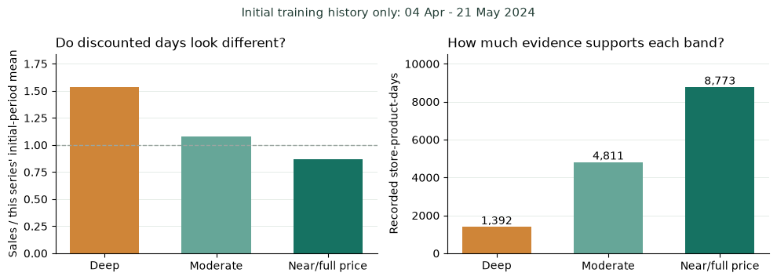

```python
eda_figure, eda_table = story.training_eda(feat)
display(eda_table)
plt.show()
```

> **Decision:** retain variation in price and recent trading context, while treating stockout signals as evidence about availability. These observations support a forecasting investigation, not a causal estimate of price elasticity. The five-store sample remains a deliberately narrow first study.

The teammate's original exploratory table included all feature rows. This descriptive view restricts itself to the training period, so its counts or averages need not reproduce that earlier table exactly.

## 4. Turn the business question into one prediction

Imagine standing at the end of today with a particular store-product's record. We know how it sold recently, whether stock was unavailable, which discount was used, and tomorrow's calendar. We also have a candidate discount that the manager could choose. What we do not know is tomorrow's sales.

**Our prediction target, Y, is next-day normalized observed sales.** The discount is an input to the prediction, not the target. At this stage we learn to forecast sales under recorded conditions; the later decision step will replace that price input with alternative candidates.

In the tables, **yesterday means the day immediately before the target date**—the trading day that has just ended when the manager makes the decision. This keeps the feature labels anchored to the date being forecast rather than accidentally introducing a two-day lag.

| Information available by the decision time | Role in the forecast |
| --- | --- |
| Yesterday's sales, same weekday last week, recent sales averages | Describe the recent level and pattern of sales |
| Yesterday's discount, stockout hours and activity | Describe recent trading and availability |
| Tomorrow's weekday, holiday status and proposed discount | Describe the day being forecast and the proposed action |
| Tomorrow's actual sales or actual stockouts | Excluded from the predictors; these happen after the decision |

The example below is the first final-period row in store-product-date order. Its observed outcome is shown only so that we can check the forecast afterwards. The dataset does not give this anonymized product a name, so we keep its identifier rather than inventing a product story.

**Show Python for this step**

```python
example = feat[feat.split == "test"].sort_values(C.ROW_KEY).iloc[[0]]
case_key = example.iloc[0]
readable = {
    "Store": case_key.store_id, "Product": case_key.product_id,
    "Day being predicted": str(case_key["dt"].date()),
    "Yesterday's sales": case_key.sales_t, "Previous 7-day average": case_key.sales_mean7,
    "Yesterday's stockout hours": case_key.stockout_hours_t,
    "Recorded target-day price rate": case_key.discount_next,
    "Actual target-day sales (evaluation only)": case_key[C.TARGET],
}
display(pd.DataFrame(readable.items(), columns=["Case information", "Value"]))
```

|  | Case information | Value |
| --- | --- | --- |
| 0 | Store | 18 |
| 1 | Product | 11 |
| 2 | Day being predicted | 2024-06-26 |
| 3 | Yesterday's sales | 1.4 |
| 4 | Previous 7-day average | 1.25714 |
| 5 | Yesterday's stockout hours | 0.0 |
| 6 | Recorded target-day price rate | 0.989 |
| 7 | Actual target-day sales (evaluation only) | 0.6 |

### 4.1 Build the input row by hand before fitting a model

For the same store-product, look backwards from the target date. The previous day's observation becomes `sales_t`; the observation seven days earlier becomes `sales_lag7`; the average of the preceding seven observations becomes `sales_mean7`. None of these calculations uses the target day's outcome.

The next tables expose those actual observations and check the arithmetic against the saved feature row. This is the bridge from a retail record to an ML input, and also the logic behind the seven-day baseline. A different store selling the same product has its own history and its own calculation.

**Show Python for this step**

```python
case_history, feature_checks = story.feature_walkthrough(feat, example)
display(case_history)
display(feature_checks)
```

|  | Historical date | Recorded sales | Recorded price rate | Recorded stockout hours |
| --- | --- | --- | --- | --- |
| 0 | 2024-06-19 | 2.0 | 0.904 | 7 |
| 1 | 2024-06-20 | 0.9 | 0.889 | 10 |
| 2 | 2024-06-21 | 0.8 | 1.000 | 0 |
| 3 | 2024-06-22 | 1.3 | 0.882 | 0 |
| 4 | 2024-06-23 | 1.3 | 0.840 | 0 |
| 5 | 2024-06-24 | 1.1 | 0.997 | 0 |
| 6 | 2024-06-25 | 1.4 | 0.997 | 0 |

|  | Feature | Recomputed from earlier days | Saved model input | Matches |
| --- | --- | --- | --- | --- |
| 0 | sales_t | 1.40000 | 1.40000 | True |
| 1 | sales_lag7 | 2.00000 | 2.00000 | True |
| 2 | sales_mean7 | 1.25714 | 1.25714 | True |
| 3 | sales_mean3 | 1.26667 | 1.26667 | True |
| 4 | sales_mean14 | 1.15714 | 1.15714 | True |
| 5 | stockout_hours_t | 0.00000 | 0.00000 | True |

> **Decision:** construct sales history within each store-product and stop every window before the target date. The model learns a mapping from these available inputs to observed sales; the future outcome is retained separately so that we can check the prediction afterwards.

The date attached to each feature row is the day being predicted. Historical windows end before that date: the seven-day mean, for example, uses the seven preceding days. The selected raw records have no invalid price-rate or missing-value removals; the first seven days of each series are dropped to build complete lag histories. This leaves 25,896 training-period rows and 2,184 final-period rows. Every model is evaluated on the same rows. The target is copied from the source's normalized sales field; this project does not normalize it a second time.

In a daily workflow, yesterday's observed sales become available before predicting today. We therefore make rolling one-day-ahead forecasts, updating the history within each evaluation week while keeping the model fitted at that week's start. This does not claim to forecast a whole week before any of it occurs.

### 4.2 What cleaning actually changed

A cleaning rule is not evidence that a defect was present. The inherited pipeline checks duplicate store-product dates, continuous daily history and missing values; it also handles zero and above-one price rates before feature construction. In this selected cohort, the raw-data audit found no such price-rate or missing-value removals. The actual row reduction comes from the first seven dates of each series, where the required lag history is not yet available.

The table below distinguishes source checks from rows removed. We retain stockout days: dropping them would change the population under study, while keeping them means our target remains observed sales, which can be below unmet customer demand.

**Show Python for this step**

```python
cleaning = evidence["cleaning"]
display(pd.DataFrame([
    ["Selected raw store-product-day rows", cleaning["raw_selected_rows"]],
    ["Selected raw price rates above one", cleaning["raw_selected_discount_above_one_rows"]],
    ["Selected raw zero price rates", cleaning["raw_selected_zero_discount_rows"]],
    ["Missing values in audited selected columns", cleaning["raw_selected_missing_values_in_audited_columns"]],
    ["Rows removed before complete features", cleaning["rows_removed_before_saved_features"]],
    ["Saved feature rows", cleaning["saved_feature_rows"]],
], columns=["Audit item", "Count"]))
```

|  | Audit item | Count |
| --- | --- | --- |
| 0 | Selected raw store-product-day rows | 30264 |
| 1 | Selected raw price rates above one | 0 |
| 2 | Selected raw zero price rates | 0 |
| 3 | Missing values in audited selected columns | 0 |
| 4 | Rows removed before complete features | 2184 |
| 5 | Saved feature rows | 28080 |

## 5. Start with a decision a manager could make without ML

Before fitting a complex model, consider a simple forecast: **tomorrow will sell about as much as the average of the previous seven days**. A second baseline reuses sales from the same weekday last week. If machine learning cannot improve on these, extra complexity has little forecasting justification.

We use mean absolute error, or **MAE**, as the primary score: the average size of a forecast miss. Lower is better. RMSE gives greater weight to large misses, so we keep it as a second check rather than assuming that the lowest MAE means every kind of error improved.

To resemble predicting the future, we compare on later dates. Each of five weekly validation rounds trains on all earlier available feature rows. The mean validation MAE selects the model; the final week then provides a common benchmark. Preprocessing is fitted within each training fold.

**A limit we carry throughout:** these weeks have been used in earlier project development. The final week is an already-viewed benchmark, not an untouched holdout. Recording the new selection before its final scoring prevents new choices within this run, but cannot undo earlier exposure.

**Show Python for this step**

|  | Round | Training ends | Training rows | Scored rows |
| --- | --- | --- | --- | --- |
| 0 | Validation 1 | 2024-05-21 | 14976 | 2184 |
| 1 | Validation 2 | 2024-05-28 | 17160 | 2184 |
| 2 | Validation 3 | 2024-06-04 | 19344 | 2184 |
| 3 | Validation 4 | 2024-06-11 | 21528 | 2184 |
| 4 | Validation 5 | 2024-06-18 | 23712 | 2184 |

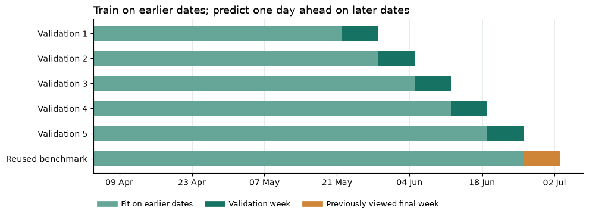

```python
timeline_figure, timeline_table = story.split_timeline(feat, plan)
display(timeline_table)
plt.show()
```

### 5.1 A future-like comparison, with a known limitation

Randomly mixing neighboring dates would put highly related histories on both sides of the comparison. Instead, each validation model sees only feature rows before its validation week. Standardization for distance-based or linear models is fitted again using that round's training rows. Every candidate sees the same target dates and is scored against the same observations.

The calendar still has two limitations: the working cohort was chosen from the whole original training period, and earlier project development already viewed the final week. We therefore describe the final week as a shared benchmark, even though the model fits themselves follow time order.

**Show Python for this step**

```python
display(comparison[comparison.model.isin(["7-day mean", "Same weekday"])][
    ["model", "validation_mae", "test_mae", "test_rmse"]].rename(columns={"test_mae":"final_period_mae", "test_rmse":"final_period_rmse"}))
```

|  | model | validation_mae | final_period_mae | final_period_rmse |
| --- | --- | --- | --- | --- |
| 0 | 7-day mean | 0.32840 | 0.31418 | 0.52089 |
| 1 | Same weekday | 0.41502 | 0.39975 | 0.61707 |

The recent seven-day mean is the stronger baseline here. We use it as the main reference while continuing to report both. The next question is whether the discount and context inputs add enough information to improve on that recent-sales average.

## 6. What the teammate's work established

Aashish's notebook develops this question through k-nearest neighbours, Random Forest and CatBoost, then a blend of the two tree models. Each model offers a different way to learn from comparable past cases. The point of the comparison is to find out which added complexity is useful on the same later dates.

| Method | The plain-language idea | Why include it? |
| --- | --- | --- |
| k-nearest neighbours | Find similar past trading days and average their sales | An intuitive reference for learning from comparable cases |
| Random Forest | Average many trees that divide trading conditions into groups | Capture nonlinear relationships and reduce reliance on a single tree |
| CatBoost | Add small trees sequentially to improve the current prediction | Test whether correcting earlier errors helps |
| A 50/50 blend | Average the forest and CatBoost predictions | Test whether their errors offset each other |

The teammate also documented tuning choices and found that weather did not improve his validation results. We inherit his ten-input reference design and its settings. This narrative revision does not claim to rerun or rediscover every earlier tuning experiment. The table below comes from the matched V2 experiment, which refitted those reference designs alongside the extension.

**Show Python for this step**

```python
reference_names = ["7-day mean", "Same weekday", "kNN reference", "Teammate RF", "Teammate CatBoost", "Teammate blend 50/50"]
display(metrics.loc[reference_names, ["validation_mae", "test_mae", "test_rmse"]].rename(
    columns={"test_mae":"final_period_mae", "test_rmse":"final_period_rmse"}))
```

| model | validation_mae | final_period_mae | final_period_rmse |
| --- | --- | --- | --- |
| 7-day mean | 0.32840 | 0.31418 | 0.52089 |
| Same weekday | 0.41502 | 0.39975 | 0.61707 |
| kNN reference | 0.31198 | 0.30398 | 0.49002 |
| Teammate RF | 0.30244 | 0.29235 | 0.46459 |
| Teammate CatBoost | 0.30330 | 0.28965 | 0.46026 |
| Teammate blend 50/50 | 0.30125 | 0.28923 | 0.45926 |

All four learned reference methods improve on the seven-day average in this comparison. The blend's advantage over its individual tree models is small. Before extending that design, we follow the key questions that led to these reference models. The next three sections use the teammate's saved tuning artifacts; their charts can be recreated without claiming to perform a new tuning run.

### 6.1 kNN: are comparable past days enough?

**Question.** Can we predict tomorrow by finding past days with similar recent sales, price conditions and calendar context? k-nearest neighbours finds the closest training rows after scaling their features, then averages their observed sales. It does not build a tree or update weights through gradient descent.

**Technical choice.** A small neighborhood can chase noise; a large one can average over days that are not sufficiently comparable. Scaling matters because distance adds differences across features. A weather measurement with a large numerical range should not dominate distance merely because of its units.

**Evidence.** The inherited comparison varies the number of neighbors and feature sets on the same five validation weeks. The following chart makes the effect of including weather visible instead of simply announcing a final feature list.

**Show Python for this step**

|  | Recorded design | Validation MAE |
| --- | --- | --- |
| 0 | k=25, equal weights, with weather | 0.32668 |
| 1 | k=25, equal weights, without weather | 0.31198 |
| 2 | 7-day baseline | 0.32840 |

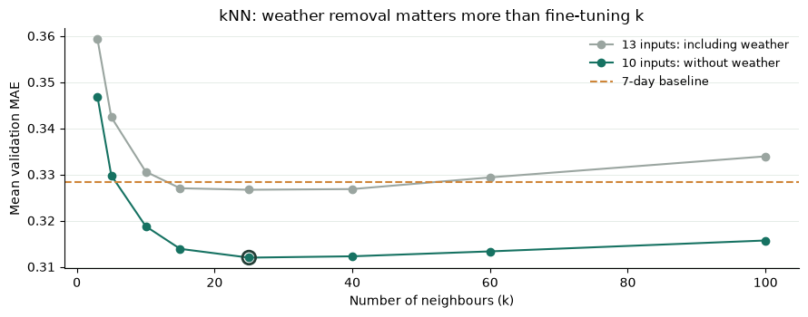

```python
knn_figure, knn_table = story.teammate_knn(ROOT)
display(knn_table)
plt.show()
```

For equal feature weights and 25 neighbors, the saved validation MAE falls from about **0.32668 with weather to 0.31198 without weather**. The seven-day baseline is about 0.32840. This is evidence that those weather inputs did not help this particular setup; it does not imply that weather never affects food demand. After weather is removed, the useful neighborhood-size region is relatively broad.

> **Inherited choice:** 25 neighbors, uniform neighbor averaging, equal feature weights, Euclidean distance and a training-fitted standard scaler, using the ten base inputs. The technical appendix demonstrates actual neighbors and the averaging calculation for our real case.

### 6.2 Random Forest: can many conditional rules improve on similarity?

**Question.** Two trading days need not be close in every feature to share a useful sales pattern. Could rules such as “recent average above this level, then a particular price range” capture those patterns better? A regression tree partitions training rows with feature thresholds and predicts a leaf's mean sales. A Random Forest averages many such trees, trained with resampled rows and feature subsets.

**Technical choice.** Deep trees and tiny leaves can memorize peculiar days. Limiting depth or requiring more observations per leaf makes a prediction depend on a broader group. The teammate compared these controls; the color scale below is deliberately labeled because the score differences are small.

**Show Python for this step**

|  | max_depth | min_leaf | mae | folds_beating_baseline |
| --- | --- | --- | --- | --- |
| 0 | 10 | 3 | 0.30244 | 5 |
| 1 | 10 | 5 | 0.30270 | 5 |
| 4 | 15 | 3 | 0.30296 | 5 |
| 5 | 15 | 5 | 0.30307 | 5 |

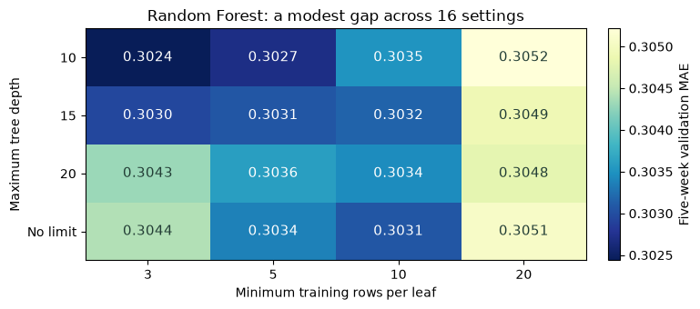

```python
forest_figure, forest_table = story.teammate_rf(ROOT)
display(forest_table)
plt.show()
```

The saved depth/leaf grid selects **depth 10 and at least three rows per leaf**, with validation MAE about **0.30244**. The earlier leaf/features comparison also favored leaving out weather. These results justify a useful nonlinear reference, while the small gaps between nearby settings discourage a claim that one setting is universally best.

> **Inherited choice:** 300 trees, depth 10, minimum leaf size three, half the input features considered at a split and squared-error splitting. Adding forest trees averages more estimates; it is not the sequential error-correction process that we test next.

### 6.3 CatBoost: can small corrections outperform a forest?

**Question.** Instead of averaging independently built trees, what if each new tree improves the current prediction? CatBoost adds shallow trees sequentially, taking a smaller step controlled by the learning rate. This makes it suitable for interactions in tabular data, but also creates a point at which extra fitting can follow training noise rather than improve a later week's forecasts.

**Technical choice.** Depth controls each tree's complexity; learning rate controls the step size; iterations control how many steps are taken. The teammate's first grid tested 12 settings, then a 27-setting grid explored shallower, slower designs. The saved learning curve is a diagnostic from one validation fold, not a fresh set of independent test weeks.

**Show Python for this step**

|  | depth | learning_rate | iterations | mae |
| --- | --- | --- | --- | --- |
| 25 | 5 | 0.03 | 500 | 0.30330 |
| 5 | 3 | 0.02 | 1000 | 0.30336 |
| 14 | 4 | 0.02 | 1000 | 0.30338 |
| 23 | 5 | 0.02 | 1000 | 0.30347 |
| 16 | 4 | 0.03 | 500 | 0.30371 |

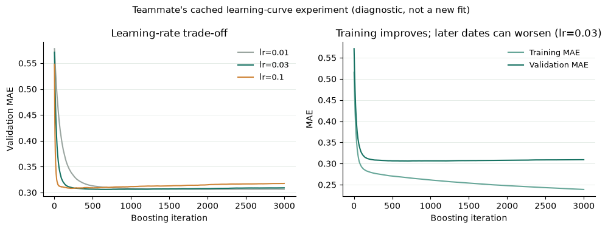

```python
cat_figure, cat_table = story.teammate_catboost(ROOT)
display(cat_table)
plt.show()
```

The inherited reference uses **depth 5, learning rate 0.03 and 500 iterations**, with validation MAE about **0.30330**. Its score is close to the forest's. The learning curves show why more iterations are not automatically better: a decreasing training error can coexist with a later rise in validation error. That is a useful overfitting demonstration, not proof that every product has reached a prediction ceiling.

> **Inherited choice:** retain the small, regularized CatBoost reference and examine whether it adds something to the forest. It uses ten numeric inputs; the store/product categorical IDs are introduced in Lisa's extension, so the original reference does not test their benefit.

### 6.4 Keep simpler and alternative models in the comparison

Our shared project also asks whether different model families behave differently. The matched V2 experiment therefore retains **Ridge, one decision tree and HistGradientBoosting**, rather than comparing only two closely related tree ensembles. These are declared reference designs, not freshly optimized settings. They answer different questions:

| Reference | What it tests | Important choice |
| --- | --- | --- |
| Ridge | Whether a regularized linear relationship is sufficient | Scale inputs; penalize large coefficients |
| Decision tree | Whether a small collection of conditional rules is sufficient | Depth and leaf-size limits |
| HistGradientBoosting | Whether another sequential tree implementation competes | Learning rate, number of stages and leaf count |
| Monotonic HistGradientBoosting | Whether imposing a non-increasing response to price rate helps | Higher price rate cannot raise the prediction when other inputs are held fixed |

The monotonic constraint is a modeling assumption that can make scenario behavior easier to interpret. It does not remove confounding, and it should not be declared successful without checking forecast error.

**Show Python for this step**

```python
other_references = ["7-day mean", "Ridge", "Decision tree", "HistGradientBoosting", "Monotonic HistGBR"]
display(metrics.loc[other_references, ["validation_mae", "test_mae", "test_rmse"]].rename(
    columns={"test_mae":"final_period_mae", "test_rmse":"final_period_rmse"}))
```

| model | validation_mae | final_period_mae | final_period_rmse |
| --- | --- | --- | --- |
| 7-day mean | 0.32840 | 0.31418 | 0.52089 |
| Ridge | 0.31553 | 0.30725 | 0.50280 |
| Decision tree | 0.32359 | 0.32222 | 0.49868 |
| HistGradientBoosting | 0.30585 | 0.29006 | 0.45692 |
| Monotonic HistGBR | 0.30598 | 0.29030 | 0.45655 |

Ridge improves on the recent-sales baseline, while the single tree's final-period MAE is worse than that baseline. HistGradientBoosting is competitive, but neither it nor its monotonic variant wins the declared validation comparison. A visually appealing or theoretically sensible constraint is not enough to justify selecting it over the measured alternatives.

> **Decision:** keep these comparisons as evidence of what the added complexity buys. The close forest and CatBoost scores motivate a more specific question: can we improve the description of recent trading, and align learning with the error measure we actually use to choose a model?

## 7. Lisa's extension: give the model a better account of recent trading

Two products can have the same seven-day average but very different recent paths: one may be rising, the other falling. A stable series and an erratic series can also share the same average. We add past-only features to make these differences visible, together with store and product identifiers treated as categories.

| Proposed change | Reason to test it | How we interpret the evidence |
| --- | --- | --- |
| More recent history and variation | Distinguish short-term direction, variability and longer-running level | The feature/ID package changes several things together; its comparison also changes regularization, so individual effects are not isolated |
| Train CatBoost with MAE loss | Align training more closely with the primary selection metric | Compare RMSE and MAE loss with the same extended inputs and other CatBoost settings |
| Blend the best standalone design with RF | Let different prediction errors partly offset | Compare three declared RF weights using validation MAE |

The additions include sales two and three days ago, averages over three and fourteen days, seven-day variation, a short-versus-long recent trend, previous discount averages and recent stockout-day counts. They use only earlier observations. There are 18 numeric inputs plus two categorical IDs in the extended design.

The bounded experiment contains eleven standalone designs, four blends and two baselines. The familiar Ridge, decision tree and HistGradientBoosting models remain in the comparison; the full table is in the appendix. Candidates and blend rules were recorded before this run's final-period scoring.

We first ask a controlled question: when the extended CatBoost inputs and other settings are unchanged, does MAE training improve average absolute error, and what happens to large errors?

**Show Python for this step**

```python
loss_rows = ["CatBoost history + IDs", "CatBoost history + IDs MAE"]
display(metrics.loc[loss_rows, ["validation_mae", "test_mae", "test_rmse"]].rename(
    columns={"test_mae":"final_period_mae", "test_rmse":"final_period_rmse"}))
```

| model | validation_mae | final_period_mae | final_period_rmse |
| --- | --- | --- | --- |
| CatBoost history + IDs | 0.29715 | 0.28423 | 0.45500 |
| CatBoost history + IDs MAE | 0.29449 | 0.28458 | 0.46006 |

MAE training improves validation MAE in this controlled comparison, so it is the stronger standalone candidate under our selection rule. Yet its final-period MAE and RMSE are worse than the RMSE-trained extended version. This is why we specify the selection criterion first and show secondary outcomes rather than treating every change as an improvement.

MAE training estimates a conditional median. Later, when we multiply its forecast by a price rate, that product will be a decision proxy, not a claim about mathematically expected revenue.

### 7.1 Separate the reasons: history, identity, price and activity

The original V2 package changed several things together. To explain it more carefully, we add a **validation-only diagnostic experiment** with the same five expanding folds and fixed CatBoost depth, iterations, learning rate, regularization and seed. It compares ten base inputs, added history, added categorical IDs, and alternative loss functions. It then removes the proposed discount, previous-day activity, or both from the full MAE design.

Our expectations are explicit: recent-history features may capture changes that a seven-day mean misses; IDs may capture recurring store-product context; and the proposed discount may add predictive information beyond recent sales. Removing activity tests whether yesterday's activity adds anything after those other inputs are present. A result in the opposite direction is useful evidence too.

This is a new explanatory check on already-used validation weeks. It does **not** score the final period, change the canonical 17-method comparison, select new blend weights or create an untouched evaluation.

**Show Python for this step**

```python
ablation_dir = ROOT / "results" / "story_ablation"
subprocess.run([sys.executable, str(ROOT / "scripts" / "run_story_ablation.py"), "--verify-only"],
               check=True, capture_output=True, text=True)
ablation = pd.read_csv(ablation_dir / "summary.csv")
ablation_contrasts = pd.read_csv(ablation_dir / "contrasts.csv")
display(ablation[["variant", "n_features", "loss", "validation_mae", "validation_rmse", "folds"]])
display(ablation_contrasts[["contrast", "reference", "changed", "mae_delta",
                            "relative_mae_change_pct", "weeks_changed_lower_mae", "folds"]])
print("Contrast convention: changed minus reference; a negative MAE difference is an improvement.")
print("Input/output provenance and validation metrics verified; no final-period scoring or reselection.")
```

|  | variant | n_features | loss | validation_mae | validation_rmse | folds |
| --- | --- | --- | --- | --- | --- | --- |
| 0 | Base 10 / RMSE | 10 | RMSE | 0.30455 | 0.47221 | 5 |
| 1 | History 18 / RMSE | 18 | RMSE | 0.29781 | 0.46141 | 5 |
| 2 | Full 20 / RMSE | 20 | RMSE | 0.29715 | 0.46015 | 5 |
| 3 | Full 20 / MAE | 20 | MAE | 0.29449 | 0.45912 | 5 |
| 4 | No proposed discount / MAE | 19 | MAE | 0.31081 | 0.49954 | 5 |
| 5 | No previous activity / MAE | 19 | MAE | 0.29537 | 0.46333 | 5 |
| 6 | No proposed discount or previous activity / MAE | 18 | MAE | 0.31044 | 0.49931 | 5 |

|  | contrast | reference | changed | mae_delta | relative_mae_change_pct | weeks_changed_lower_mae | folds |
| --- | --- | --- | --- | --- | --- | --- | --- |
| 0 | Add eight history features | Base 10 / RMSE | History 18 / RMSE | -0.00674 | -2.21263 | 5 | 5 |
| 1 | Add store and product IDs | History 18 / RMSE | Full 20 / RMSE | -0.00066 | -0.22097 | 3 | 5 |
| 2 | Change RMSE loss to MAE | Full 20 / RMSE | Full 20 / MAE | -0.00266 | -0.89411 | 4 | 5 |
| 3 | Remove proposed target-day discount | Full 20 / MAE | No proposed discount / MAE | 0.01631 | 5.53937 | 0 | 5 |
| 4 | Remove previous-day activity | Full 20 / MAE | No previous activity / MAE | 0.00088 | 0.29888 | 1 | 5 |
| 5 | Remove both action/context fields | Full 20 / MAE | No proposed discount or previous activity / MAE | 0.01595 | 5.41606 | 0 | 5 |

```
Contrast convention: changed minus reference; a negative MAE difference is an improvement.
Input/output provenance and validation metrics verified; no final-period scoring or reselection.
```

**Show Python for this step**

```python
ablation_by_variant = ablation.set_index("variant")
explanatory_pairs = [
    ("Base 10 / RMSE", "History 18 / RMSE", "Adding recent-history features"),
    ("History 18 / RMSE", "Full 20 / RMSE", "Adding store and product IDs after history"),
    ("Full 20 / RMSE", "Full 20 / MAE", "Changing the full design from RMSE to MAE training"),
    ("Full 20 / MAE", "No proposed discount / MAE", "Removing tomorrow's proposed discount"),
    ("Full 20 / MAE", "No previous activity / MAE", "Removing yesterday's activity flag"),
]
findings = []
for reference, changed, label in explanatory_pairs:
    before = float(ablation_by_variant.loc[reference, "validation_mae"])
    after = float(ablation_by_variant.loc[changed, "validation_mae"])
    direction = "lower" if after < before else "higher" if after > before else "unchanged"
    relative = abs(after-before)/before*100
    findings.append(f"- **{label}:** average validation MAE moves from {before:.5f} to {after:.5f} "
                    f"({relative:.2f}% {direction}).")
display(Markdown("\n".join(findings)))
```

- **Adding recent-history features:** average validation MAE moves from 0.30455 to 0.29781 (2.21% lower).

- **Adding store and product IDs after history:** average validation MAE moves from 0.29781 to 0.29715 (0.22% lower).

- **Changing the full design from RMSE to MAE training:** average validation MAE moves from 0.29715 to 0.29449 (0.89% lower).

- **Removing tomorrow's proposed discount:** average validation MAE moves from 0.29449 to 0.31081 (5.54% higher).

- **Removing yesterday's activity flag:** average validation MAE moves from 0.29449 to 0.29537 (0.30% higher).

Read each contrast as a narrow question. Adding history while other settings are fixed estimates the predictive effect of that feature group under this protocol. Adding IDs then tests their extra contribution conditional on that history. Removing a price or activity input tests the information it contributes to the fitted prediction; it is **not** a causal estimate of a discount's effect on sales.

> **Decision:** use this diagnostic to explain which parts of the design have evidence behind them, and which do not. Retain the previously selected model for the reported benchmark and policy examples. Reusing validation folds limits how strongly we can generalize these additional findings.

### 7.2 Derive the blend instead of guessing its weights

Averaging helps only when the models make sufficiently different errors. If both underpredict the same sales spike, their average will also miss it. We examine errors from validation rows predicted by models that were fitted on earlier dates, and then compare only the declared blend choices.

There are two distinct pieces of evidence. In the teammate's original sweep, 50/50 was a simple near-best choice: the exact lowest saved validation MAE occurs at 60% RF. In V2, we combine the validation-best non-RF standalone design with RF at three declared weights: 25%, 50% and 75% RF. These are different experiments with different CatBoost components.

**Show Python for this step**

|  | RF weight | CatBoost weight | Validation MAE |
| --- | --- | --- | --- |
| 0 | 0.00 | 1.00 | 0.29449 |
| 1 | 0.25 | 0.75 | 0.29402 |
| 2 | 0.50 | 0.50 | 0.29530 |
| 3 | 0.75 | 0.25 | 0.29814 |
| 4 | 1.00 | 0.00 | 0.30244 |

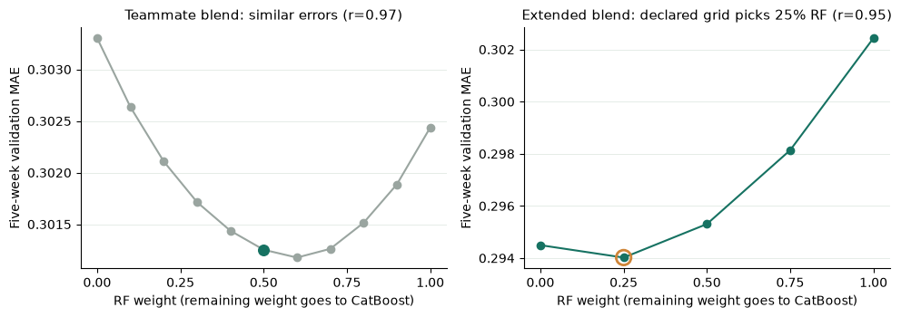

```python
blend_figure, blend_table = story.blend_diagnostics(ROOT)
display(blend_table)
plt.show()
```

The V2 validation comparison favors **25% RF and 75% extended MAE CatBoost** among those declared choices. This places more weight on the stronger standalone forecast while retaining a contribution from the forest. The weights are selected by validation performance; they are not inferred from feature importance, and they do not represent discount percentages.

> **Decision:** lock that blend for the final-period comparison. The small differences between neighboring candidates are a reason to avoid describing the weights as universally optimal. The later worked example shows the two member predictions and the exact weighted-average arithmetic.

## 8. Did the extension improve the forecast?

The validation rule selects a blend of **25% Random Forest and 75% extended CatBoost trained with MAE**. Those weights combine two forecasts; they are not a 25% or 75% discount on a product.

We now compare it with the baselines and the teammate's blend on the same cases. This is the answer to the forecasting part of the project, before making any claim about a pricing policy.

**Show Python for this step**

| model | validation_mae | final_period_mae | final_period_rmse |
| --- | --- | --- | --- |
| 7-day mean | 0.32840 | 0.31418 | 0.52089 |
| Same weekday | 0.41502 | 0.39975 | 0.61707 |
| Teammate blend 50/50 | 0.30125 | 0.28923 | 0.45926 |
| RF + validation best (25/75) | 0.29402 | 0.28339 | 0.45605 |

```
Final-period MAE reduction versus 7-day mean: 9.80%
Final-period MAE reduction versus Teammate blend 50/50: 2.02%
Validation weeks better than the teammate blend: 5 out of 5
```

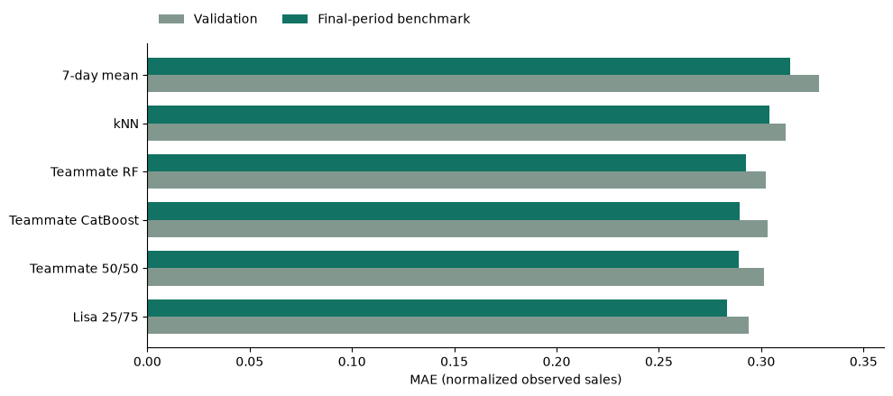

```python
show = ["7-day mean", "Same weekday", "Teammate blend 50/50", winner]
display(metrics.loc[show, ["validation_mae", "test_mae", "test_rmse"]].rename(
    columns={"test_mae":"final_period_mae", "test_rmse":"final_period_rmse"}))
folds = pd.read_csv(OUT / "validation_folds.csv")
paired = folds[folds.model.isin(["Teammate blend 50/50", winner])].pivot(index="fold", columns="model", values="mae")
for ref in ["7-day mean", "Teammate blend 50/50"]:
    improvement = 100*(metrics.loc[ref,"test_mae"]-metrics.loc[winner,"test_mae"])/metrics.loc[ref,"test_mae"]
    print(f"Final-period MAE reduction versus {ref}: {improvement:.2f}%")
print("Validation weeks better than the teammate blend:", int((paired[winner] < paired["Teammate blend 50/50"]).sum()), "out of 5")
plot_names = ["7-day mean", "kNN reference", "Teammate RF", "Teammate CatBoost", "Teammate blend 50/50", winner]
fig, ax = plt.subplots(figsize=(10, 4.5)); pos = np.arange(len(plot_names)); width = .36
ax.barh(pos+width/2, metrics.loc[plot_names,"validation_mae"], width, label="Validation", color="#82988f")
ax.barh(pos-width/2, metrics.loc[plot_names,"test_mae"], width, label="Final-period benchmark", color="#127263")
ax.set_yticks(pos, ["7-day mean", "kNN", "Teammate RF", "Teammate CatBoost", "Teammate 50/50", "Lisa 25/75"])
ax.invert_yaxis(); ax.set_xlim(0,.36); ax.set_xlabel("MAE (normalized observed sales)")
ax.legend(frameon=False, loc="lower left", bbox_to_anchor=(0, 1.02), ncol=2)
ax.spines[["top","right"]].set_visible(False)
fig.tight_layout(); plt.show()
```

The selected blend has lower MAE than the teammate's blend in all five validation weeks and improves final-period MAE by about 2%. That is a modest, measured gain within this cohort. It does not establish that the weights are universally optimal, or that every metric, product or future store improves.

Before handing this forecast to a manager, we need to examine where it still misses and what happens when we actually ask it to choose a discount.

## 9. Look at the mistakes before trusting the recommendation

Average error can hide the cases a manager cares about most. Deep discounts coincide with larger sales spikes and are harder to forecast here. We inspect every recorded discount band, rather than selecting only the band in which a model looks good. We also show the largest misses, chosen mechanically by absolute error.

Target-day stockouts may help explain a miss after the fact. They are used for diagnosis only and are never given to the model before its forecast.

**Show Python for this step**

```python
slices = pd.read_csv(OUT / "error_slices.csv")
display(slices[slices["slice"] == "discount"][["value","model","mae","rmse","n"]])
largest = pd.read_csv(OUT / "largest_errors.csv")
display(largest[C.ROW_KEY + [C.TARGET,"discount_next","target_stockout_hours",winner,"selected_abs_error"]].head(3))
```

|  | value | model | mae | rmse | n |
| --- | --- | --- | --- | --- | --- |
| 36 | none_or_small | 7-day mean | 0.27105 | 0.39351 | 1186 |
| 37 | none_or_small | Teammate blend 50/50 | 0.23298 | 0.32635 | 1186 |
| 38 | none_or_small | RF + validation best (25/75) | 0.22907 | 0.32248 | 1186 |
| 39 | moderate | 7-day mean | 0.30332 | 0.44538 | 757 |
| 40 | moderate | Teammate blend 50/50 | 0.29821 | 0.43218 | 757 |
| 41 | moderate | RF + validation best (25/75) | 0.29278 | 0.43624 | 757 |
| 42 | deep | 7-day mean | 0.56059 | 1.03619 | 241 |
| 43 | deep | Teammate blend 50/50 | 0.53784 | 0.89476 | 241 |
| 44 | deep | RF + validation best (25/75) | 0.52122 | 0.88049 | 241 |

|  | store_id | product_id | dt | target_sales | discount_next | target_stockout_hours | RF + validation best (25/75) | selected_abs_error |
| --- | --- | --- | --- | --- | --- | --- | --- | --- |
| 0 | 343 | 38 | 2024-06-29 | 10.3 | 0.505 | 9 | 4.73391 | 5.56609 |
| 1 | 343 | 122 | 2024-06-30 | 10.6 | 0.633 | 0 | 6.48249 | 4.11751 |
| 2 | 18 | 122 | 2024-06-30 | 10.1 | 0.633 | 0 | 6.11697 | 3.98303 |

### 9.1 Are the difficult cases concentrated somewhere?

A manager needs to understand how a forecast can fail, not just its average score. The diagnostic below keeps the same final-period cases and examines errors across relevant groups. A large absolute miss on a high-sales day can dominate RMSE; a small average improvement can coexist with weak performance in a particular store or discount band.

These groups are inspected after the outcome is known. They help explain reliability and future data needs; they do not become additional inputs that were somehow available before the original forecast.

**Show Python for this step**

|  | band | rows | mae | actual_mean | forecast_mean |
| --- | --- | --- | --- | --- | --- |
| 0 | Deep | 241 | 0.52122 | 1.65876 | 1.56738 |
| 1 | Moderate | 757 | 0.29278 | 0.99721 | 0.98232 |
| 2 | Near/full | 1186 | 0.22907 | 0.81015 | 0.78237 |

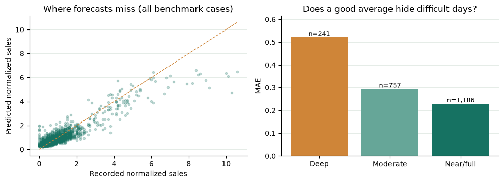

```python
error_figure, error_table = story.error_diagnostics(feat, test_predictions, winner)
display(error_table)
plt.show()
```

> **Decision:** report the error slices and a mechanically chosen failure alongside the overall result. Better average prediction does not justify removing manual review from the decision process. We also avoid treating a few stores or one unusually hard week as evidence about every future location.

These errors matter because a recommendation based on an understated sales spike or censored history can be misleading. A model that wins on average still needs decision checks. The next step exposes a second problem: predicting recorded sales and choosing a new price are different tasks.

## 10. The turning point: a good forecaster can still over-recommend discounts

To compare prices, we hold the known context fixed and change only tomorrow's candidate discount. The menu includes full price, 5% off, 10% off and deeper reductions. Each candidate receives a sales forecast. Selecting the candidate with the highest forecast sounds natural if the goal is to sell more.

But a model can learn that deep-discount days have high sales without learning that a deep discount would cause high sales on an ordinary day. Managers chose historical discounts for reasons that are not all in the dataset. Simply setting a different price input does not remove that selection problem.

This was a central finding in the teammate's storyline. The table below repeats the diagnostic using **Lisa's already-saved candidate forecasts**, without refitting models or observing any new sales. It compares choosing the largest forecast with choosing the largest price-rate-times-forecast proxy, both before and after requiring historical price support. The manager-review rules have not yet been applied.

**Show Python for this step**

```python
naive_rows = []
for supported_only in [False, True]:
    pool = responses[responses.supported].copy() if supported_only else responses.copy()
    pool["value_proxy"] = pool.rate * pool.selected_sales
    for criterion in ["selected_sales", "value_proxy"]:
        # Highest rate first gives a milder discount if forecasts tie exactly.
        ordered = pool.sort_values(C.ROW_KEY + [criterion,"rate"], ascending=[True]*len(C.ROW_KEY)+[False,False])
        chosen = ordered.drop_duplicates(C.ROW_KEY)
        naive_rows.append({"Search": "Historically supported rates" if supported_only else "All candidate rates",
            "Choose highest": "Forecast sales" if criterion == "selected_sales" else "Sales-value proxy",
            "Cases": len(chosen), "Discount recommended (%)": round(100*(chosen.rate<1).mean(),1),
            "Choices without support": int((~chosen.supported).sum())})
display(pd.DataFrame(naive_rows))
```

|  | Search | Choose highest | Cases | Discount recommended (%) | Choices without support |
| --- | --- | --- | --- | --- | --- |
| 0 | All candidate rates | Forecast sales | 2184 | 100.0 | 2062 |
| 1 | All candidate rates | Sales-value proxy | 2184 | 99.8 | 1816 |
| 2 | Historically supported rates | Forecast sales | 2184 | 100.0 | 0 |
| 3 | Historically supported rates | Sales-value proxy | 2184 | 99.4 | 0 |

Historical support limits where the model extrapolates, but does not by itself settle whether a discount is justified. We therefore treat the prediction as an input to a transparent decision process, not as a direct instruction to the manager. Even that process will remain provisional until business outcomes under the recommended policy can be observed.

## 11. From a sales forecast to a specific discount

The manager needs an answer such as **10% off**, not just a forecast number. The extension uses the following sequence to decide when it can offer that answer.

| Step | Decision and reason |
| --- | --- |
| Check supply | A stockout yesterday triggers review: sales may have been censored and tomorrow's availability needs checking |
| Check relevant history | Require at least three training days within ±0.025 of each candidate rate, plus a supported full-price comparator |
| Check the trade-off | Require at least 5% predicted sales gain and at least 95% of the full-price sales-value proxy |
| Check model agreement | The selected blend and both reference models must independently pass those same comparisons |
| Choose the depth | Among passing candidates, find the highest predicted sales; choose the mildest discount within 1% of that best forecast |

The sales-value proxy is **price rate × predicted normalized sales**. It allows a relative comparison for the same product, but is not money or profit. The thresholds are illustrative business choices, not values learned to be optimal. Model agreement is a sensitivity check, not a calibrated confidence interval.

This also explains what we changed in the teammate's stock rules. A stockout does not prove tomorrow's stock is fresh, and a week without a stockout does not prove the stock is a week old. We request a supply review when necessary and do not infer inventory age from these signals.

**Show Python for this step**

|  | Step | Reason |
| --- | --- | --- |
| 0 | 01 CHECK SUPPLY | Recent stockout?\nAsk for supply review. |
| 1 | 02 CHECK HISTORY | Is this candidate price\nsupported by past days? |
| 2 | 03 COMPARE MODELS | Do sales-gain and value\nchecks pass in all mo... |
| 3 | 04 CHOOSE / DEFER | Pick a mild near-best discount\nor explain why... |

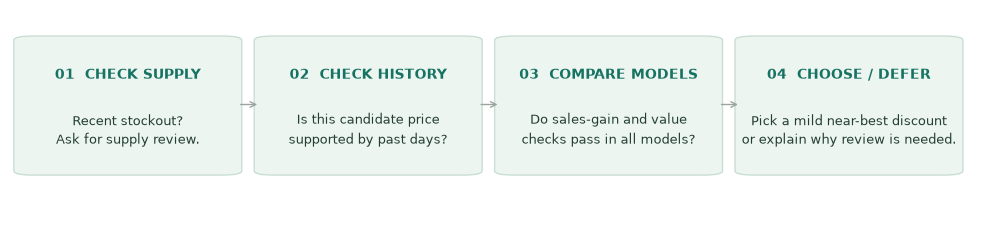

```python
decision_figure, decision_table = story.decision_flow()
display(decision_table)
plt.show()
```

## 12. Follow one real case to a 10% discount

We use the **first supported recommendation in store-product-date order**, not the case with the largest predicted gain: store 18, product 11, on 26 June 2024. This is the same case introduced earlier. Its previous-day stockout hours are zero, so it passes the initial supply-review check.

Read the following table as a set of alternatives for that one day. A price rate of 0.90 means **10% off** (九折). Only the recorded rate has an actual sales outcome; the alternative forecasts are scenarios.

**Show Python for this step**

|  | Price rate | Nearby historical days | Predicted sales | Predicted gain (%) | Selected value / full price | RF value / full price | Decision |
| --- | --- | --- | --- | --- | --- | --- | --- |
| 0 | 1.00 | 33 | 1.07370 | 0.00000 | 1.00000 | 1.00000 | Full-price comparator |
| 1 | 0.95 | 10 | 1.24016 | 15.50412 | 1.09729 | 1.02956 | Passes; lower forecast sales |
| 2 | 0.90 | 12 | 1.29123 | 20.26016 | 1.08234 | 0.98412 | Selected |
| 3 | 0.85 | 23 | 1.38568 | 29.05702 | 1.09698 | 0.94597 | Fails at least one model's gain/value check |
| 4 | 0.80 | 5 | 1.43157 | 33.33119 | 1.06665 | 0.93669 | Fails at least one model's gain/value check |
| 5 | 0.75 | 0 | 1.47889 | 37.73783 | 1.03303 | 0.89711 | Too little nearby price history |
| 6 | 0.70 | 0 | 1.71976 | 60.17197 | 1.12120 | 0.90256 | Too little nearby price history |
| 7 | 0.60 | 0 | 1.92641 | 79.41871 | 1.07651 | 0.80946 | Too little nearby price history |

```
Recommendation: 10% off; predicted sales 1.291.
```

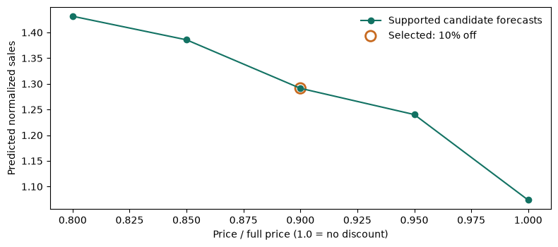

```python
case = recs[recs.status == "recommend_discount"].sort_values(C.ROW_KEY).iloc[0]
mask = (responses.store_id == case.store_id) & (responses.product_id == case.product_id) & (responses.dt == case["dt"])
case_curve = responses.loc[mask].sort_values("rate", ascending=False).copy()
full = case_curve[case_curve.rate == 1.].iloc[0]
settings = plan["decision_parameters"]
case_curve["selected_gain_pct"] = 100*(case_curve.selected_sales/full.selected_sales-1)
case_curve["selected_value_share"] = case_curve.rate*case_curve.selected_sales/full.selected_sales
case_curve["rf_value_share"] = case_curve.rate*case_curve.rf_sales/full.rf_sales
case_curve["passes_all_models"] = case_curve.supported & (case_curve.rate < 1)
for col in ["selected_sales","rf_sales","cat_sales"]:
    case_curve["passes_all_models"] &= (case_curve[col]/full[col]-1 >= settings["min_sales_gain"])
    case_curve["passes_all_models"] &= (case_curve.rate*case_curve[col]/full[col] >= settings["min_value_share"])
def explain(row):
    if row.rate == 1: return "Full-price comparator"
    if not row.supported: return "Too little nearby price history"
    if not row.passes_all_models: return "Fails at least one model's gain/value check"
    return "Selected" if np.isclose(row.rate,case.recommended_rate) else "Passes; lower forecast sales"
case_curve["Decision"] = case_curve.apply(explain,axis=1)
display(case_curve[["rate","support_days","selected_sales","selected_gain_pct","selected_value_share","rf_value_share","Decision"]].rename(columns={
    "rate":"Price rate", "support_days":"Nearby historical days", "selected_sales":"Predicted sales",
    "selected_gain_pct":"Predicted gain (%)", "selected_value_share":"Selected value / full price",
    "rf_value_share":"RF value / full price"}).reset_index(drop=True))
print(f"Recommendation: {100*(1-case.recommended_rate):.0f}% off; predicted sales {case.predicted_sales:.3f}.")
fig, ax = plt.subplots(figsize=(8,3.6)); supported = case_curve[case_curve.supported]
ax.plot(supported.rate,supported.selected_sales,"o-",color="#127263",label="Supported candidate forecasts")
ax.scatter([case.recommended_rate],[case.predicted_sales],s=110,facecolors="none",edgecolors="#c76a20",linewidths=2,label="Selected: 10% off")
ax.set_xlabel("Price / full price (1.0 = no discount)"); ax.set_ylabel("Predicted normalized sales")
ax.legend(frameon=False); fig.tight_layout(); plt.show()
```

Why stop at 10% off when 15% or 20% off predicts more sales? In this case, the Random Forest reference puts those deeper candidates below the required 95% of full-price value. They therefore fail the agreement rule. Still deeper candidates lack enough nearby historical price observations. Both 5% and 10% off pass, and 10% off has the higher selected sales forecast by more than the near-tie allowance.

This is a concrete recommendation with a traceable reason. It is **not proof that nine-tenths of full price is the true optimal price**. For this day, the observed sales record belongs to the actual recorded rate, not to every alternative in the table.

## 13. A useful assistant must also know when to defer

The next table shows the first case, again by key order, where previous-day stockouts require a supply review. Giving that case an explicit reason is preferable to silently dropping it or pretending to know how old the inventory is.

**Show Python for this step**

```python
display(recs[recs.status == "review_stockout"].sort_values(C.ROW_KEY)[C.ROW_KEY+["status","reason"]].head(1))
counts = pd.DataFrame(policy["status_counts"].items(),columns=["Decision", "Cases"])
counts["Share (%)"] = 100*counts.Cases/policy["rows"]
display(counts)
no_stockout = feat[feat.split == "test"][C.ROW_KEY+["stockout_hours_t"]].merge(recs,on=C.ROW_KEY,validate="one_to_one")
no_stockout = no_stockout[no_stockout.stockout_hours_t < settings["stockout_hours_review_threshold"]]
print(f"All {len(recs):,} input cases receive an explicit output.")
print(f"Automatic decision coverage: {policy['decision_coverage']:.1%}")
print(f"Among {len(no_stockout):,} cases without yesterday's stockout, {(no_stockout.status == 'recommend_discount').mean():.1%} still recommend a discount.")
```

|  | store_id | product_id | dt | status | reason |
| --- | --- | --- | --- | --- | --- |
| 2 | 18 | 11 | 2024-06-28 | review_stockout | Recent censored sales; verify tomorrow's suppl... |

|  | Decision | Cases | Share (%) |
| --- | --- | --- | --- |
| 0 | recommend_discount | 1179 | 53.98352 |
| 1 | review_stockout | 967 | 44.27656 |
| 2 | review_model_disagreement | 38 | 1.73993 |

```
All 2,184 input cases receive an explicit output.
Automatic decision coverage: 54.0%
Among 1,217 cases without yesterday's stockout, 96.9% still recommend a discount.
```

The checks produce a recommendation on about 54% of all cases and a review on the remainder. Complete output coverage is not the same as automatic decision coverage.

There is a substantial unresolved weakness: **96.9% of cases without a previous-day stockout still receive a discount recommendation**, and none of the current cases select keep-full-price. The rules make the process more explicit, but have not established that it reliably identifies days when a discount is genuinely beneficial. Agreement among models trained on similar observational data can preserve the same bias.

### 13.1 Would different thresholds tell a different story?

The 5% gain hurdle, 95% value floor and previous-day stockout threshold are explicit assumptions. They were not learned to be business-optimal. We therefore replay a small sensitivity comparison on the **same saved scenario forecasts**, changing policy checks rather than fitting another sales model.

This asks whether recommendation coverage and discount depth depend heavily on those choices. It does not discover a better policy by observing what customers would have done. No alternative-policy sales, profit or waste outcomes are available for these historical cases.

**Show Python for this step**

|  | scenario | changed_parameters | rows | discount_count | full_price_count | review_count | discount_share | full_price_share | review_share | discount_share_nonstockout | mean_recommended_rate |
| --- | --- | --- | --- | --- | --- | --- | --- | --- | --- | --- | --- |
| 0 | Saved policy | {} | 2184 | 1179 | 0 | 1005 | 0.53984 | 0.00000 | 0.46016 | 0.96878 | 0.80445 |
| 1 | Sales gain >=10% | {"min_sales_gain": 0.1} | 2184 | 1146 | 5 | 1033 | 0.52473 | 0.00229 | 0.47299 | 0.94166 | 0.80170 |
| 2 | Sales gain >=20% | {"min_sales_gain": 0.2} | 2184 | 994 | 64 | 1126 | 0.45513 | 0.02930 | 0.51557 | 0.81676 | 0.79029 |
| 3 | Value floor >=100% | {"min_value_share": 1.0} | 2184 | 1158 | 4 | 1022 | 0.53022 | 0.00183 | 0.46795 | 0.95152 | 0.81222 |
| 4 | Value floor >=105% | {"min_value_share": 1.05} | 2184 | 1055 | 48 | 1081 | 0.48306 | 0.02198 | 0.49496 | 0.86689 | 0.82137 |
| 5 | Support >=5 days | {"min_support_days": 5} | 2184 | 1164 | 0 | 1020 | 0.53297 | 0.00000 | 0.46703 | 0.95645 | 0.82637 |
| 6 | Support >=10 days | {"min_support_days": 10} | 2184 | 926 | 0 | 1258 | 0.42399 | 0.00000 | 0.57601 | 0.76089 | 0.85232 |
| 7 | Milder within 5% | {"near_optimal_sales_tolerance": 0.05} | 2184 | 1179 | 0 | 1005 | 0.53984 | 0.00000 | 0.46016 | 0.96878 | 0.81442 |
| 8 | Review at >=4h stockout | {"stockout_hours_review_threshold": 4} | 2184 | 1329 | 0 | 855 | 0.60852 | 0.00000 | 0.39148 | 0.96878 | 0.80440 |
| 9 | Review at >=8h stockout | {"stockout_hours_review_threshold": 8} | 2184 | 1699 | 0 | 485 | 0.77793 | 0.00000 | 0.22207 | 0.96878 | 0.80715 |

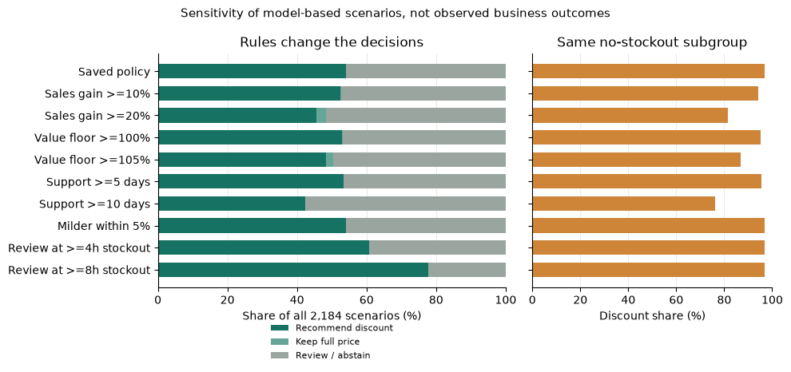

```python
subprocess.run([sys.executable, str(ROOT / "scripts" / "build_story_diagnostics.py"), "--verify-only"],
               check=True, capture_output=True, text=True)
sensitivity_figure, sensitivity_table = story.policy_sensitivity(ROOT)
display(sensitivity_table)
plt.show()
```

> **Decision:** keep the canonical thresholds and expose their influence. The sensitivity table is a discussion aid for a manager deciding what additional evidence is needed; it is not a leaderboard of realized business returns. A threshold that recommends fewer discounts is not automatically better, just as a threshold that recommends more is not evidence of higher sales.

## 14. The improvement has a boundary: other stores

The original five stores share one city. After locking the selected model, we asked whether it would also help elsewhere. A fixed ordering of eligible training-data keys selected 100 series outside city 0. The models were still trained only on the original cohort; no new-store outcomes were used for tuning. Earlier daily observations from those new stores supplied their lag inputs, as required for daily prediction.

This check covers 700 evaluation rows in 93 new stores across 16 other cities, including 47 product IDs not seen by the fitted models. It is a transfer stress test, not a claim that no group member ever viewed these public records during the project's history.

**Show Python for this step**

```python
transfer_dir = ROOT / "results" / "v2_transfer"
display(pd.read_csv(transfer_dir/"summary.csv")[["model","mae","rmse","rows"]])
```

|  | model | mae | rmse | rows |
| --- | --- | --- | --- | --- |
| 0 | 7-day mean | 0.29667 | 0.48356 | 700 |
| 1 | Same weekday | 0.36263 | 0.57550 | 700 |
| 2 | Teammate blend 50/50 | 0.28842 | 0.47096 | 700 |
| 3 | RF + validation best (25/75) | 0.28902 | 0.48863 | 700 |

The new blend does **not** beat the teammate's blend in this check. Its RMSE is also worse than the seven-day mean. We keep the original validation-selected design and report the failure rather than switching models after seeing these outcomes. The current evidence supports a modest forecasting improvement in the original cohort, not a broadly superior fresh-food pricing system.

## 15. What the manager can take away

We have a reproducible way to turn recent observations into a sales forecast, compare supported price scenarios, and explain a specific discount or review decision. The extension improves the original-cohort forecast and makes the decision checks traceable. It also exposes why that is only part of the business problem.

A real pilot would need reliable availability, replenishment, expiry and cost information. It would also need prospective evidence, such as an appropriately designed pricing experiment, to estimate what the recommended discounts actually change. We cannot infer realized profit or waste reduction from these forecast errors or hypothetical response curves.

The contribution is therefore a tested forecasting comparison and a transparent decision-support prototype, with a worked example recommending 10% off and documented failure cases. A manager can inspect its reasoning; the present evidence does not justify automatically rolling it out to every store.

The narrative follows Aashish's progression from forecasting to a discount what-if. Lisa's separate extension adds history and ID features, the controlled loss comparison, a bounded blend comparison, explicit review outputs and the transfer check. The original notebook and helper modules remain available and credited.

## Technical appendix A. How the model produces a number

The main story can be read without the following mechanics. They are included so the recommendation can be explained and reproduced during the demonstration.

For one input row $x$, a Random Forest averages predictions from bootstrap-trained decision trees. Each tree uses feature thresholds to reach a leaf; its leaf prediction is a training-target average. CatBoost adds trees sequentially: $F_m(x)=F_{m-1}(x)+\eta h_m(x)$, where $F_m$ is the prediction after step $m$, $h_m$ is the next tree, and $\eta$ is the learning rate. Its categorical machinery handles store and product IDs as categories in the extended design.

The selected forecast is $\hat y=w\hat y_{RF}+(1-w)\hat y_{CB}$, where $w=0.25$, $\hat y_{RF}$ is the forest forecast and $\hat y_{CB}$ the extended CatBoost forecast. The forecast concerns normalized observed sales. MAE training targets a conditional median rather than an expected-demand guarantee.

Below we refit only those two already-selected members on the original training feature rows. We show their predictions for the earlier real case at its recorded price, the blend arithmetic and the first forest tree's actual path. This example uses the included feature table and needs no full raw-data download.

**Show Python for this step**

```python
training = feat[feat.split == "train"]
specs = {s["name"]: s for s in plan["candidates"]}
members = selection["blend_weights"].get(winner,{winner:1.})
live_models = {}; example_values = []
from threadpoolctl import threadpool_limits
for name, weight in members.items():
    spec = specs[name]
    with threadpool_limits(limits=4):
        model = v2.estimator(spec).fit(training[v2.columns(spec)],training[C.TARGET])
    live_models[name] = model
    prediction = float(v2.predict(model,example,spec)[0])
    example_values.append({"Member":name,"Weight":weight,"Prediction":prediction,"Weighted part":weight*prediction})
example_table = pd.DataFrame(example_values); display(example_table)
live_prediction = example_table["Weighted part"].sum()
saved_case = test_predictions[(test_predictions.store_id == case_key.store_id) &
    (test_predictions.product_id == case_key.product_id) & (test_predictions.dt == case_key["dt"])].iloc[0]
print(f"Blend: {live_prediction:.6f}; observed outcome: {case_key[C.TARGET]:.6f}")
print("Replay difference from saved forecast:",abs(live_prediction-saved_case[winner]))
assert np.isclose(live_prediction,saved_case[winner],atol=1e-6)
forest = live_models.get("Teammate RF")
if forest is not None:
    x = example[C.FEATURES].to_numpy(); tree = forest.estimators_[0]; leaf = tree.apply(x)[0]
    print("First forest tree's leaf prediction:",float(tree.tree_.value[leaf,0,0]))
    print("Forest mean across",len(forest.estimators_),"trees:",float(np.mean([t.predict(x)[0] for t in forest.estimators_])))
    for node in tree.decision_path(x).indices:
        feature = tree.tree_.feature[node]
        if feature >= 0:
            value, threshold = x[0,feature],tree.tree_.threshold[node]
            print(f"{C.FEATURES[feature]} = {value:.4f} {'<=' if value <= threshold else '>'} {threshold:.4f}")
```

|  | Member | Weight | Prediction | Weighted part |
| --- | --- | --- | --- | --- |
| 0 | Teammate RF | 0.25 | 1.24649 | 0.31162 |
| 1 | CatBoost history + IDs MAE | 0.75 | 1.20780 | 0.90585 |

```
Blend: 1.217470; observed outcome: 0.600000
Replay difference from saved forecast: 0.0
First forest tree's leaf prediction: 1.1382456140350878
Forest mean across 300 trees: 1.2464884870414898
sales_mean7 = 1.2571 <= 1.7500
sales_mean7 = 1.2571 > 0.8493
discount_next = 0.9890 > 0.5550
discount_next = 0.9890 <= 0.9990
sales_mean7 = 1.2571 > 1.1364
weekday_next = 2.0000 <= 4.5000
discount_next = 0.9890 > 0.7230
sales_lag7 = 2.0000 > 1.7500
sales_mean7 = 1.2571 <= 1.5643
sales_mean_to_date = 1.1756 <= 1.1924
```

### A.1 A second worked example: actual kNN neighbors

The kNN reference answers the same prediction question using a different mechanism. For numeric input feature $j$, standardize $x_j$ as $z_j=(x_j-\mu_j)/s_j$, where $\mu_j$ and $s_j$ are the training-set mean and standard deviation. Compare the target row with training row $i$ using Euclidean distance $d_i=\sqrt{\sum_j(z_j-z_{ij})^2}$, where $z_{ij}$ is training row $i$'s standardized value of feature $j$.

If $N_{25}(x)$ denotes the 25 closest training rows to target input $x$, the prediction is $\hat y(x)=\frac{1}{25}\sum_{i\in N_{25}(x)}y_i$, where $y_i$ is neighbor $i$'s observed sales. The neighbors can come from other store-products because the reference compares their numeric trading features. Its scaler is fitted only on the original training rows, never on the target outcome.

The following calculation uses the same real target case. It makes distance, neighbor selection and the average visible, without claiming that similar observed days identify a causal price effect. Only the first five neighbors are shown; the sum and prediction use all 25.

**Show Python for this step**

```python
neighbors, neighbor_calculation = story.live_knn_example(feat, example)
display(neighbors)
display(neighbor_calculation)
```

|  | store_id | product_id | dt | target_sales | Standardized Euclidean distance |
| --- | --- | --- | --- | --- | --- |
| 0 | 343 | 419 | 2024-04-17 | 1.2 | 0.38862 |
| 1 | 18 | 715 | 2024-05-29 | 1.5 | 0.42552 |
| 2 | 18 | 99 | 2024-06-19 | 1.4 | 0.46864 |
| 3 | 182 | 578 | 2024-05-15 | 1.4 | 0.52609 |
| 4 | 154 | 122 | 2024-04-24 | 1.0 | 0.56718 |

|  | Calculation | Value |
| --- | --- | --- |
| 0 | Neighbours used | 25.00 |
| 1 | Sum of their observed targets | 28.50 |
| 2 | Sum / 25 | 1.14 |
| 3 | Pipeline prediction | 1.14 |

The result can now be explained in two ways: the forest/boosting blend combines learned conditional predictions, whereas kNN averages selected historical outcomes. Both ultimately produce the same type of output—normalized observed sales—so they can be compared against the same target and baseline. The earlier validation results decide which prediction design to use, not how persuasive an individual worked example looks.

## Technical appendix B. Metrics, inputs and the full comparison

For $n$ evaluated rows with observed sales $y_i$ and forecasts $\hat y_i$:

$$MAE=\frac1n\sum_i|y_i-\hat y_i|,\qquad RMSE=\sqrt{\frac1n\sum_i(y_i-\hat y_i)^2}.$$

WAPE is $\sum_i|y_i-\hat y_i|/\sum_i|y_i|$. Lower is better. Validation MAE selects the design; RMSE and WAPE provide additional error perspectives. The full comparison below retains both baselines first.

Rolling features are shifted before aggregation, so they exclude the target day's sales. The ten base inputs match the teammate implementation, including **yesterday's** activity flag. The older main-branch implementation instead used target-day planned activity; identical baseline scores do not establish identical input definitions.

**Show Python for this step**

```python
display(comparison[["model","validation_mae","test_mae","test_rmse","test_wape","selected"]])
display(pd.DataFrame({"Group":["Base"]*len(C.FEATURES)+["Additional history"]*len(v2.EXTRA)+["Categorical ID"]*len(v2.IDS),
                      "Feature":C.FEATURES+v2.EXTRA+v2.IDS}))
display(pd.DataFrame(plan["candidates"]).fillna("—"))
display(paired)
```

|  | model | validation_mae | test_mae | test_rmse | test_wape | selected |
| --- | --- | --- | --- | --- | --- | --- |
| 0 | 7-day mean | 0.32840 | 0.31418 | 0.52089 | 0.32436 | False |
| 1 | Same weekday | 0.41502 | 0.39975 | 0.61707 | 0.41270 | False |
| 2 | Ridge | 0.31553 | 0.30725 | 0.50280 | 0.31720 | False |
| 3 | Decision tree | 0.32359 | 0.32222 | 0.49868 | 0.33266 | False |
| 4 | HistGradientBoosting | 0.30585 | 0.29006 | 0.45692 | 0.29945 | False |
| 5 | kNN reference | 0.31198 | 0.30398 | 0.49002 | 0.31383 | False |
| 6 | Teammate RF | 0.30244 | 0.29235 | 0.46459 | 0.30182 | False |
| 7 | Teammate CatBoost | 0.30330 | 0.28965 | 0.46026 | 0.29903 | False |
| 8 | Main CatBoost | 0.30355 | 0.28754 | 0.45110 | 0.29685 | False |
| 9 | CatBoost MAE | 0.30273 | 0.28844 | 0.46459 | 0.29778 | False |
| 10 | CatBoost history + IDs | 0.29715 | 0.28423 | 0.45500 | 0.29344 | False |
| 11 | CatBoost history + IDs MAE | 0.29449 | 0.28458 | 0.46006 | 0.29379 | False |
| 12 | Monotonic HistGBR | 0.30598 | 0.29030 | 0.45655 | 0.29970 | False |
| 13 | Teammate blend 50/50 | 0.30125 | 0.28923 | 0.45926 | 0.29860 | False |
| 14 | RF + validation best (25/75) | 0.29402 | 0.28339 | 0.45605 | 0.29257 | True |
| 15 | RF + validation best (50/50) | 0.29530 | 0.28425 | 0.45548 | 0.29345 | False |
| 16 | RF + validation best (75/25) | 0.29814 | 0.28714 | 0.45834 | 0.29644 | False |

|  | Group | Feature |
| --- | --- | --- |
| 0 | Base | sales_t |
| 1 | Base | sales_lag7 |
| 2 | Base | sales_mean7 |
| 3 | Base | sales_mean_to_date |
| 4 | Base | stockout_hours_t |
| 5 | Base | discount_t |
| 6 | Base | discount_next |
| 7 | Base | activity_t |
| 8 | Base | holiday_next |
| 9 | Base | weekday_next |
| 10 | Additional history | sales_lag2 |
| 11 | Additional history | sales_lag3 |
| 12 | Additional history | sales_mean3 |
| 13 | Additional history | sales_mean14 |
| 14 | Additional history | sales_std7 |
| 15 | Additional history | sales_trend |
| 16 | Additional history | discount_mean7 |
| 17 | Additional history | stockout_days7 |
| 18 | Categorical ID | store_category |
| 19 | Categorical ID | product_category |

|  | name | kind | features | alpha | depth | leaf | monotonic | iterations | lr | loss | l2 |
| --- | --- | --- | --- | --- | --- | --- | --- | --- | --- | --- | --- |
| 0 | Ridge | ridge | base | 10.0 | — | — | — | — | — | — | — |
| 1 | Decision tree | tree | base | — | 6.0 | 20.0 | — | — | — | — | — |
| 2 | HistGradientBoosting | hist | base | — | — | — | False | — | — | — | — |
| 3 | kNN reference | knn | base | — | — | — | — | — | — | — | — |
| 4 | Teammate RF | rf | base | — | — | — | — | — | — | — | — |
| 5 | Teammate CatBoost | cat | base | — | 5.0 | — | — | 500.0 | 0.03 | RMSE | 3.0 |
| 6 | Main CatBoost | cat | base | — | 4.0 | — | — | 400.0 | 0.05 | RMSE | 5.0 |
| 7 | CatBoost MAE | cat | base | — | 5.0 | — | — | 500.0 | 0.03 | MAE | 3.0 |
| 8 | CatBoost history + IDs | cat | history_ids | — | 5.0 | — | — | 500.0 | 0.03 | RMSE | 5.0 |
| 9 | CatBoost history + IDs MAE | cat | history_ids | — | 5.0 | — | — | 500.0 | 0.03 | MAE | 5.0 |
| 10 | Monotonic HistGBR | hist | base | — | — | — | True | — | — | — | — |

| model fold | RF + validation best (25/75) | Teammate blend 50/50 |
| --- | --- | --- |
| 1 | 0.28155 | 0.28759 |
| 2 | 0.28126 | 0.29022 |
| 3 | 0.32512 | 0.33419 |
| 4 | 0.27917 | 0.29023 |
| 5 | 0.30299 | 0.30404 |

### B.1 What is optimized, and which settings matter?

For a linear model, $\hat y_i=b+\sum_j\beta_j z_{ij}$, where $b$ is the intercept, $\beta_j$ a learned coefficient and $z_{ij}$ a standardized input. Ridge chooses these coefficients to reduce $\sum_i(y_i-\hat y_i)^2+\alpha\sum_j\beta_j^2$. The first term penalizes squared prediction error; the second shrinks large coefficients, with strength $\alpha$. The intercept is not in that penalty.

A squared-error regression tree chooses feature thresholds that reduce the sum of within-leaf squared deviations. For leaf $L$, this quantity is $\sum_{i\in L}(y_i-\bar y_L)^2$, where $\bar y_L$ is the mean training target in that leaf. A split is useful when the two child leaves reduce that total. A forest uses the same kind of split repeatedly, with resampling and feature subsampling, then averages trees.

Boosting updates an existing prediction by adding a tree that reduces its chosen training loss. For squared error, large residuals receive more influence; absolute error gives each error magnitude linear influence. RMSE and squared-error loss have the same minimizer for a fixed set of predictions, but the chosen implementation and optimization procedure still matter. CatBoost also uses regularization and, in the extended design, category-specific machinery for the store/product IDs. The selected mixed-loss blend is neither a guaranteed conditional mean nor an exact conditional median.

| Design | Main settings in the recorded experiment | Why the settings matter |
| --- | --- | --- |
| Ridge | StandardScaler; alpha 10 | Make the coefficient penalty meaningful across input scales |
| Decision tree | Depth 6; minimum 20 rows per leaf | Limit narrow, unstable rules |
| kNN reference | StandardScaler; 25 neighbors; equal weights | Control distance comparability and local averaging |
| Random Forest | 300 trees; depth 10; minimum leaf 3; half the features per split | Average varied trees while limiting each tree's complexity |
| HistGradientBoosting | 300 stages; learning rate 0.05; at most 15 leaves; minimum leaf 20; L2 1 | Balance sequential corrections against complexity |
| Monotonic HistGBR | Same settings; non-increasing prediction in proposed price rate | Test an explicit price-response shape restriction |
| Reference CatBoost | 500 stages; depth 5; learning rate 0.03; L2 3; RMSE loss | Preserve the teammate's locked reference |
| Extended CatBoost | Same depth/stages/rate; L2 5; 18 numeric inputs and two IDs; RMSE or MAE | Test richer context and a controlled loss contrast |

All compared forecasts are clipped at zero according to the recorded common postprocessing rule. This avoids negative predicted sales; it does not guarantee appropriate price-response behavior. The full candidate table above includes the additional main-branch CatBoost reference and loss variants.

### B.2 Why these comparisons do not all answer the same question

The baseline comparison asks whether fitting a model improves forecasting at all. A fixed-family comparison asks whether another representation helps under its declared settings. The inherited tuning grids vary settings within a family. The controlled extended-loss comparison changes only the loss. The new validation-only diagnostic isolates feature groups more carefully, while the original V2 history/ID package also changed regularization. Keeping these distinctions visible prevents a broad claim such as “CatBoost is best” from replacing the actual evidence.

The final choice remains **minimum average validation MAE under the declared protocol**, with final-period RMSE, slices and transfer results used to describe strengths and weaknesses. None of those forecast comparisons is a direct evaluation of the business reward from deploying the discount policy.

Ridge uses standardized numeric inputs with a coefficient penalty. The single decision tree is a simple nonlinear reference. HistGradientBoosting tests another sequential tree approach, including a variant with a monotonic price-rate constraint. kNN scales inputs within each training fold before finding nearby training cases. The model factories preserve the declared settings; there is no fresh parameter search inside this narrative notebook.

The paired bootstrap analysis below resamples store-product series, keeping each series' seven final observations together. It is descriptive: shared-store shocks and repeated model-selection optimism are not corrected. Five stores and one week are too little to establish broad reliability.

**Show Python for this step**

```python
display(json.loads((OUT/"paired_comparison.json").read_text()))
display(slices[(slices["slice"] == "store") & (slices.model == winner)][["value","mae","rmse","n"]])
```

```
{'selected_minus_teammate_mae': -0.005842771261994179,
 'series_bootstrap_95pct_interval': [-0.010104686129866775,
  -0.0011266001930648228],
 'limitation': 'Descriptive 7-day, 5-store interval; shared-store correlation and selection optimism not corrected.'}
```

|  | value | mae | rmse | n |
| --- | --- | --- | --- | --- |
| 23 | 18 | 0.28720 | 0.45645 | 448 |
| 26 | 154 | 0.24521 | 0.35712 | 420 |
| 29 | 182 | 0.29080 | 0.46107 | 427 |
| 32 | 235 | 0.26912 | 0.38771 | 441 |
| 35 | 343 | 0.32235 | 0.57915 | 448 |

## Technical appendix C. Reproduce the evidence

This is a narrative revision of the saved experiment, not a new tuning round. The forecast target, cohort, fitted-design selection and reported benchmark scores are unchanged. The selection-funnel artifact can be rebuilt from the verified public raw files with `scripts/build_story_evidence.py`. The default notebook reads saved evidence, refits the two selected blend members for the live worked example, and fits the fixed kNN reference for its neighbor calculation. It does not rerun the historical tuning grids or the separate validation-only feature diagnostic.

From a complete repository copy:

```
docker compose up --build -d
docker compose exec lab python scripts/jupyter_v2_url.py
docker compose exec lab python scripts/run_v2.py --verify-only
docker compose exec lab python scripts/execute_lisa_notebook.py
```

To regenerate the complete experiment and story evidence:

```
docker compose exec lab python scripts/download_public_data.py
docker compose exec lab python scripts/run_v2.py
docker compose exec lab python scripts/run_v2_transfer_check.py --force
docker compose exec lab python scripts/run_story_ablation.py --force
docker compose exec lab python scripts/build_story_evidence.py
docker compose exec lab python scripts/build_story_diagnostics.py
docker compose exec lab python scripts/build_lisa_notebook.py
docker compose exec lab python scripts/execute_lisa_notebook.py
```

The raw files are downloaded once and reused after verification. Building the image initially needs network access; the saved-data demonstration runs offline. The report and lab use separate image snapshots: export changes made inside the lab container before recreating it, and rebuild the report image to show regenerated output. The README contains the complete export and data-volume instructions.

**Show Python for this step**

```python
display(pd.DataFrame(plan["environment"].items(),columns=["Package","Recorded experiment version"]))
print("Saved experiment verification:",verification["status"])
print("Feature rows:",len(feat),"; validation predictions:",verification["oof_rows"],"; final-period cases:",verification["test_rows"])
print("Selection was recorded before this run's final scoring:",selection["selected_before_test_scoring_utc"])
print("Original full experiment fits:",json.loads((OUT/"run_receipt.json").read_text()).get("fitted_models"))
```

|  | Package | Recorded experiment version |
| --- | --- | --- |
| 0 | python | 3.12.13 |
| 1 | numpy | 2.5.3 |
| 2 | pandas | 3.0.6 |
| 3 | scikit-learn | 1.9.1 |
| 4 | catboost | 1.2.10 |
| 5 | pyarrow | 25.0.1 |

```
Saved experiment verification: passed
Feature rows: 28080 ; validation predictions: 10920 ; final-period cases: 2184
Selection was recorded before this run's final scoring: 2026-10-09T17:48:26.124294+00:00
Original full experiment fits: 66
```

The supplied brief requires each member's factual contribution and generative-AI declaration. See `docs/CONTRIBUTIONS_TEMPLATE.md`, the requirements checklist and the Chinese code walkthroughs. Generative AI assisted substantially with code, review and presentation; automated verification does not replace the authors' personal understanding. Nothing in this notebook represents a Moodle submission.

### Personal understanding and declarations before submission

Each member should be able to explain the business question, the five-store selection, one input row, the validation rule, the selected blend, and the reason for either the example discount or a review decision. A successful automated run checks execution; it does not establish personal understanding.

The final submitted notebook or report must include each member's own short paragraph stating their actual contribution, the generative-AI assistance used and how they checked it. The linked template is still a place for those factual accounts, not a substitute for them. Any discussion of feasibility with teaching staff should likewise be recorded only if it actually occurred.